# Taller evaluado de repaso para el Primer Parcial

Análisis de Datos

Author

Jaume Maimó Bibiloni

### Primer paso

Este trabajo tiene como base de datos una muestra de 100 jugadores de volei junto con las siguientes variables

4 variables quantitativas:

- Horas de entrenamiento semanal.
- Altura máxima de ataque.
- Velocidad del jugador (segundos en recorrer 20 segundos).
- Numero de puntuntos anotados en un partido.

3 ordinales (serà una escala del 1 al 5 con niveles desde “Muy bajo” a “Muy alto”):

- Nivel de compromiso.
- Nivel de motivación.
- Nivel de experiencia.

Y finalmente 2 variables nominales:

- Posición.
- Gènero “Masculino” o “Femenino” (són las dos categorías que existen en el mundo del voleibol).

Este estudio lo puedes encontrar en: https://github.com/JMaimo/Taller_repas_parcial.git

El objetivo general es estudiar algunas características físicas y psicològicas que afectan a la capacidad de anotar puntos de jugadores de voleibol.

Los objetivos más específicos son:

1. Comprobar si hay una relación con el tiempo de horas dedicadas al entrenamiento afecta al salto máximo vertical o al rendimiento en el partido (evaluado en puntos anotados).
2. Estudiar la relación de la motivación, la experiencia o el compromiso con la capacidad de puntuar en un partido.
3. Verificar si existen diferencias en el rendimiento entre los jugadores de voleibol en funcion de factores como el sexo o la posición que juegan.

### Segundo paso:

**Tabla 1**: Genera una tabla con al menos 100 observaciones y las variables definidas en el paso anterior, asegurate que las variables cuantitativas sigan una distribución normal multivariante. A continuación, te presento un ejemplo que simula datos de una encuesta aplicada a estudiantes de secundaria sobre sus hábitos de estudio y rendimiento y que incluye información sobre su contexto de vida, como horas de sueño y tiempo de traslado a la escuela. Este ejemplo no lo debes usar en tu proyecto, solo es para darte una idea de lo que te pido hacer.

```r
media <- c(15, 300, 3, 15)  # Medias para horas_entrenamiento, altura_ataque, velocidad, puntos_anotados
covarianza <- matrix(c(10,  0.1,  1.5, 4,
                       0.1,   20, 1.2, 3,
                       1.5, 1.2, 0.5, 1,
                       4,   3, 1, 15),
                     nrow = 4, ncol = 4)

# Generamos los datos
set.seed(21)
datos_numericos <- mvrnorm(100, mu = media, Sigma = covarianza)

# Tabla con datos
rendimiento_voleibol <- data.frame(
  horas_entrenamiento = round(datos_numericos[,1], 1),
  altura_ataque = round(datos_numericos[,2], 1),
  velocidad = round(datos_numericos[,3], 1),
  puntos_anotados = round(datos_numericos[,4]),
  posicion = sample(c("Receptor", "Opuesto", "Central"), 100, replace = TRUE),
  sexo = sample(c("Masculino", "Femenino"), 100, replace = TRUE),
  nivel_compromiso = ordered(sample(1:5, 100, replace = TRUE), labels = c("Muy bajo", "Bajo", "Medio", "Alto", "Muy alto")),
  nivel_motivacion = ordered(sample(1:5, 100, replace = TRUE), labels = c("Muy bajo", "Bajo", "Medio", "Alto", "Muy alto")),
  nivel_experiencia = ordered(sample(1:5, 100, replace = TRUE), labels = c("Muy bajo", "Bajo", "Medio", "Alto", "Muy alto"))
)
rendimiento_voleibol <- as_tibble(rendimiento_voleibol) #para usar tydiverse
```

### Tercer paso

Realiza un análisis descriptivo multivariantes de tu base de datos de acuerdo a los objetivos de tu trabajo. Describe lo observado en el contexto del problema.

Primero comprovemos realmente que la distancia de Mahalanobis sigue una distribución $\chi^2$ con 4 grados de libertad (ya que por construcción siguen una distribución normal multivariante). Observémoslo gráficamente en una primera instancia:

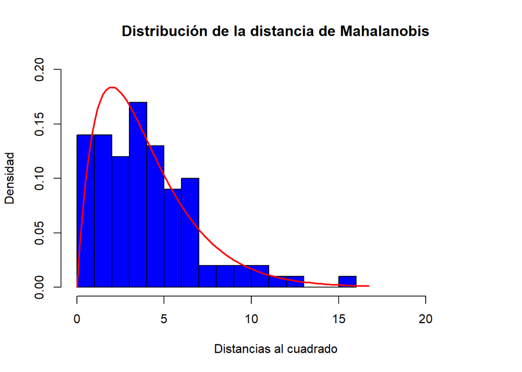

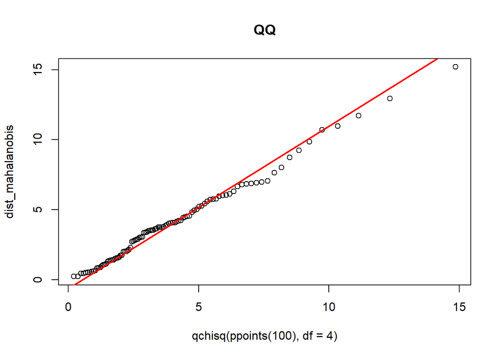

Viendo el gráfico podemos intuir que sí que sigue una $\chi ^2$. Ahora hacemos una prueba para verlo:

```r
ks.test(dist_mahalanobis, "pchisq", df = 4)
```

```
    Asymptotic one-sample Kolmogorov-Smirnov test

data:  dist_mahalanobis
D = 0.077794, p-value = 0.5804
alternative hypothesis: two-sided
```

Como tenemos un p-valor grande no podemos rechazar que sigan una distribución diferente.

Realizaremos también algun análisis para responder a los objetivos buscados: Empezaremos con un contraste de correlación entre la variable salto veritcal y el tiempo de horas dedicadas al entrenamiento. Haremos un test de Pearson ya que tenemos dos variables contínuas que siguen una distribución normal (por construcción) y veremos si existe una correlación lineal.

```r
cor_test1 <- cor.test(rendimiento_voleibol$horas_entrenamiento, rendimiento_voleibol$altura_ataque)

cor_test1
```

```
    Pearson's product-moment correlation

data:  rendimiento_voleibol$horas_entrenamiento and rendimiento_voleibol$altura_ataque
t = -0.13351, df = 98, p-value = 0.8941
alternative hypothesis: true correlation is not equal to 0
95 percent confidence interval:
 -0.2093494  0.1834182
sample estimates:
        cor
-0.01348579
```

No podemos concluir que haya una correlación entre el total de horas entradas a la semana y la altura de ataque (hipotsi nula es que la correlación entre las dos variables es 0). Puede ser debido a que tiene que ver con la altura del jugador/a, con la genética u otros factores externos.

Ahora estudiemos las horas de entrenamiento con el total de puntos por partido. Veamos un gráfico para intentar predecir o entender el resultado del test:

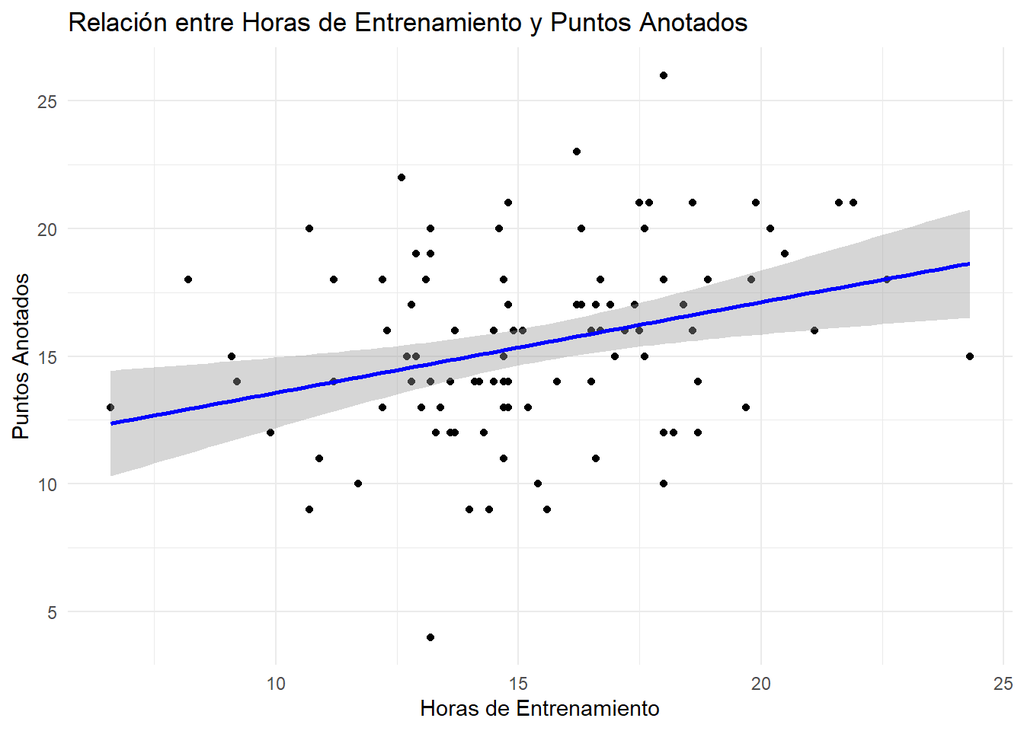

Hemos modelado la recta con un metodo de regresión lineal, cuya sombra gris es el intervalo de confianza al 95%, es decir si volviesemos a tomar muestras y ajustar el modelo, la linea azul estaría en esa franja un 95% de las veces. Si interpretamos la gráfica, vemos como más horas de entrenamiento hay, más puntos parecen anotar ya que la recta es creciente, por tanto, podemos intuir que si que hay una correlación entre las dos variables.

Veámoslo con el test adecuado:

```r
modelo_lineal <- lm(puntos_anotados ~ horas_entrenamiento, data = rendimiento_voleibol)


# Resumen del modelo
summary(modelo_lineal)
```

```
Call:
lm(formula = puntos_anotados ~ horas_entrenamiento, data = rendimiento_voleibol)

Residuals:
     Min       1Q   Median       3Q      Max
-10.7044  -2.2449   0.0298   1.8253   9.5944

Coefficients:
                    Estimate Std. Error t value Pr(>|t|)
(Intercept)          10.0261     1.7572   5.706 1.23e-07 ***
horas_entrenamiento   0.3544     0.1123   3.157  0.00212 **
---
Signif. codes:  0 '***' 0.001 '**' 0.01 '*' 0.05 '.' 0.1 ' ' 1

Residual standard error: 3.542 on 98 degrees of freedom
Multiple R-squared:  0.09232,   Adjusted R-squared:  0.08306
F-statistic: 9.968 on 1 and 98 DF,  p-value: 0.002117
```

En este caso vemos que el p-valor es menor a 0.05, por tanto podemos rechazar la hipotesis nula. Es decir, sí que hay una correlación entre las horas entrenadas y el total de puntos en un partido, de hecho el 0,3544 nos indica que por cada hora de entreno el numero de puntos notados aumenta en un 0,3544 aproximadamente.

Vamos a utilizar la prueba de correlación de Spearman para evaluar la relación entre las tres variables ordinales con la variable de puntos anotados por partido (que podemos considerar continua). Primero veamos con un grafico como se representaria:

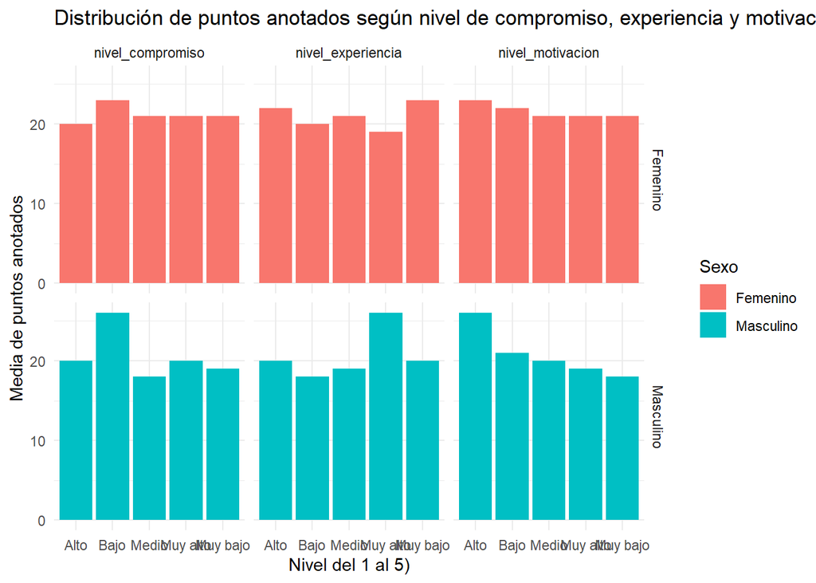

```r
# Pruebas de correlación de Spearman entre variables ordinales y puntuación
cor_motivacion_puntos <- cor.test(rendimiento_voleibol$nivel_motivacion, rendimiento_voleibol$puntos_anotados, method = "spearman")
cor_experiencia_puntos <- cor.test(rendimiento_voleibol$nivel_experiencia, rendimiento_voleibol$puntos_anotados, method = "spearman")
cor_compromiso_puntos <- cor.test(rendimiento_voleibol$nivel_compromiso, rendimiento_voleibol$puntos_anotados, method = "spearman")

# Resultados
cor_motivacion_puntos
```

```
    Spearman's rank correlation rho

data:  rendimiento_voleibol$nivel_motivacion and rendimiento_voleibol$puntos_anotados
S = 152893, p-value = 0.4142
alternative hypothesis: true rho is not equal to 0
sample estimates:
       rho
0.08255283
```

```r
cor_experiencia_puntos
```

```
    Spearman's rank correlation rho

data:  rendimiento_voleibol$nivel_experiencia and rendimiento_voleibol$puntos_anotados
S = 174078, p-value = 0.6597
alternative hypothesis: true rho is not equal to 0
sample estimates:
        rho
-0.04457011
```

```r
cor_compromiso_puntos
```

```
    Spearman's rank correlation rho

data:  rendimiento_voleibol$nivel_compromiso and rendimiento_voleibol$puntos_anotados
S = 177515, p-value = 0.5193
alternative hypothesis: true rho is not equal to 0
sample estimates:
        rho
-0.06519579
```

Como todos los p-valores son mayores a 0,05 no existen evidencias que nos permitan rechazar la hipotesis nula. Por tanto concluimos que no hay una correlación significativa entre las variables estudiadas y el numero total de puntos anotados.

Para saber si hay diferencias entre la cantidad de puntos que hace cada jugador segun su posición, haremos una Anova.

```r
# Realizamos el ANOVA para comparar los puntos anotados en función de la posición
anova_resultado <- aov(puntos_anotados ~ posicion, data = rendimiento_voleibol)

summary(anova_resultado)
```

```
            Df Sum Sq Mean Sq F value Pr(>F)
posicion     2      2   0.994   0.071  0.931
Residuals   97   1353  13.947
```

Observamos que el p-valor es alto, por lo tanto, aceptamos la hipotsesis nula: Las medias de puntos anotados son iguales para todas las posiciones. Es decir, el total de puntos que hace un jugador por partido no depende de la posición.

Hagamos un gráfico para verlo explícitamente:

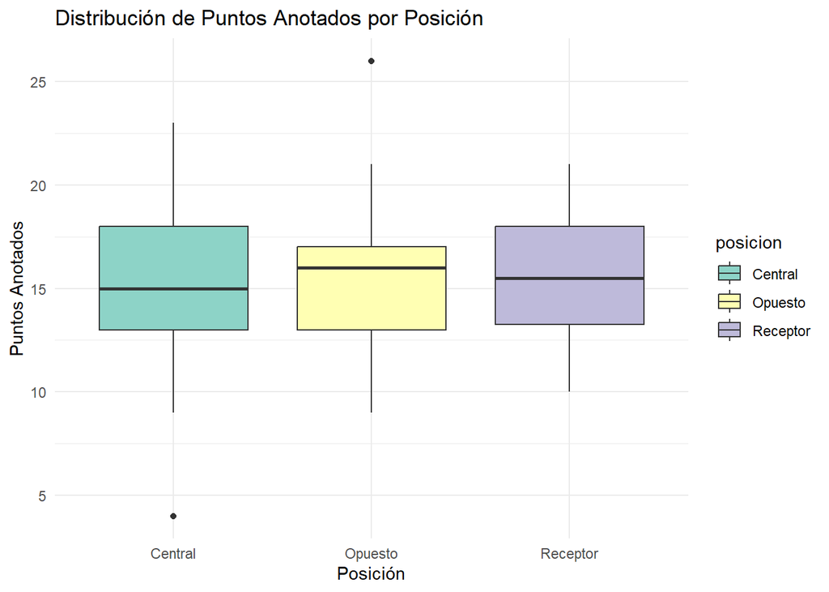

Vamos a estudiar si el total de puntos que hace un jugador, depende de la categoría que juega (estudiar por sexo), para así poder concluir el total de errores y/o bloqueos que se cometen en cada partido dependiendo de la categoria. Veámos un gráfico para hacernos una idea:

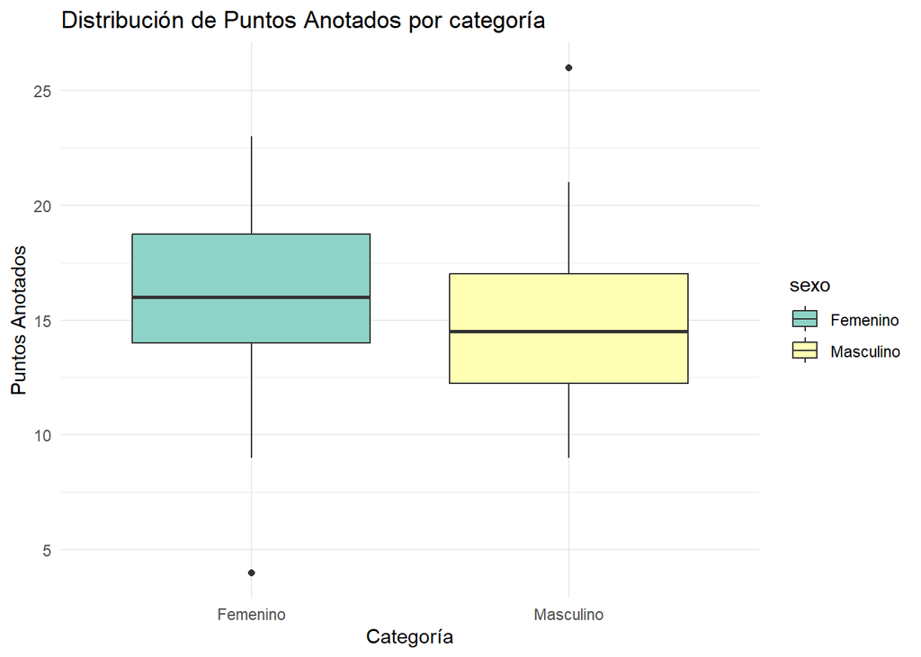

```r
# Realizamos el ANOVA para comparar los puntos anotados en función de la categoría (sexo)
anova_resultado <- aov(puntos_anotados ~ sexo, data = rendimiento_voleibol)

summary(anova_resultado)
```

```
            Df Sum Sq Mean Sq F value Pr(>F)
sexo         1   27.6   27.55   2.034  0.157
Residuals   98 1327.3   13.54
```

Veamos que tenemos un p-valor por encima del 0,05 por tanto aceptamos la hipotsesis nula: Las medias de puntos anotados no dependen del sexo. Es decir, el total de puntos que hace un jugador por partido no depende de la categoría en que juegan.

Para las variables cuantitativas de tu base de datos, calcula e interpreta la información que proporciona la varianza generalizada y la varianza total.

```r
#Cálculo de la varianza generalizada
gen_var <- det(covarianza)

#Cálculo de la varianza total
total_var <- sum(diag(covarianza))

gen_var
```

```
[1] 520.765
```

```r
total_var
```

```
[1] 45.5
```

### Cuarto paso

Selecciona una de las variables no cuantitativas y modelízala con una distribución multinomial, debes estimar sus parámetros. Utiliza el modelo para calcular la probabilidad de que ocurra un evento de interés en una muestra de tamaño 20, relevante para tu problema.

Seleccionaremos la variable no cuantitativa la posición en que juega cada jugador, que tiene tres niveles: *Receptor*, *Opuesto* o *Central*.

```r
# Calculamos las frecuencias relativas para la variable posición
tabla_posicion <- rendimiento_voleibol %>%
  count(posicion) %>%
  mutate(probabilidad = n / sum(n))



# Vemos el vector de probabilidades
tabla_posicion
```

```
# A tibble: 3 × 3
  posicion     n probabilidad
  <chr>    <int>        <dbl>
1 Central     35         0.35
2 Opuesto     35         0.35
3 Receptor    30         0.3
```

Estudiemos ahora el caso en que si cogemos una muestra de 20 jugadores, 10 sean receptores, 4 sean opuestos y 6 centrales.

```r
# Probabilidades estimadas de las categorías
prob_receptor <- tabla_posicion$probabilidad[tabla_posicion$posicion == "Receptor"]
prob_opuesto <- tabla_posicion$probabilidad[tabla_posicion$posicion == "Opuesto"]
prob_central <- tabla_posicion$probabilidad[tabla_posicion$posicion == "Central"]

# Tamaño de la muestra
tamano_muestra <- 20

# La cantidad q queremos de cada
evento_interes <- c(10, 4, 6)

# Aplicamos la fórmula de la distribución multinomial para calcular la probabilidad
probabilidad_evento <- dmultinom(evento_interes, size = tamano_muestra, prob = c(prob_receptor, prob_opuesto, prob_central))

# Mostrar la probabilidad
probabilidad_evento
```

```
[1] 0.006319909
```

### Quinto paso

Con las variables cuantitativas de tu base de datos, ajusta un modelo de regresión multivariante en la forma:

$$Y=\beta_0+\beta_1 X_1+ \cdots + \beta_p X_p + \epsilon$$
Donde $Y$ es la variable cuantitativa que deseas explicar en función del resto de variables cuantitativas registradas. Además, calcula la función de score e interpreta su resultado en el contexto del problema.

Nuestra $Y$ será la variable dependiente, que es el total de puntos anotados (variable cuantitativa), e intentaremos explicarla en función de las otras variables cuantitativas: horas de entrenamiento, altura de ataque y velocidad.

```r
# Modelo de regresión lineal múltiple
modelo <- lm(puntos_anotados ~ horas_entrenamiento + altura_ataque + velocidad, data = rendimiento_voleibol)

summary(modelo)
```

```
Call:
lm(formula = puntos_anotados ~ horas_entrenamiento + altura_ataque +
    velocidad, data = rendimiento_voleibol)

Residuals:
   Min     1Q Median     3Q    Max
-9.031 -2.281  0.086  2.259  9.969

Coefficients:
                     Estimate Std. Error t value Pr(>|t|)
(Intercept)         -46.94888   27.35016  -1.717   0.0893 .
horas_entrenamiento   0.23275    0.14254   1.633   0.1058
altura_ataque         0.18659    0.09219   2.024   0.0457 *
velocidad             0.93225    0.69957   1.333   0.1858
---
Signif. codes:  0 '***' 0.001 '**' 0.01 '*' 0.05 '.' 0.1 ' ' 1

Residual standard error: 3.354 on 96 degrees of freedom
Multiple R-squared:  0.2027,    Adjusted R-squared:  0.1778
F-statistic: 8.136 on 3 and 96 DF,  p-value: 6.985e-05
```

Es interesante ver que en este caso, el p-valor relacionado con las horas de entrenamiento es mayor a 0.05 en diferencia de cuando hemos aplicado la regresión lineal simple. Esto se debe a que lo estamos calculando con otras variables y hace que ésta se vuelva más débil y además puede que existe una correlación entre ellas. En definitiva, en este caso tendríamos que concluir que el total de horas de entrenamiento no está correlacionado con los puntos anotados por partido.

En cambio el p-valor considerando la altura de ataque máxima sí es menor a 0.05 pudiendo afirmar que tienen una correlación.

En cuanto a la velocidad, como el p-valor es mayor al 0.05, no podemos afirmar que haya la correlación que se podría esperar.

En R, la función de score no se calcula directamente como tal, pero se puede observar su comportamiento a través de los residuos del modelo.

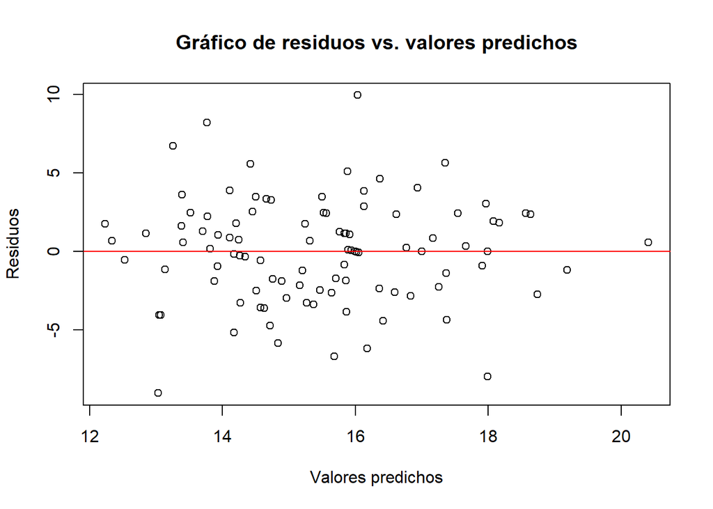

### Sexto paso

Realiza un contraste de hipótesis de dos medias multivariante que sea relevante para tu problema. Por ejemplo, podrías evaluar si el vector de medias de la variable cuantitativa de interés $Y$ es el mismo para dos niveles distintos de la variable no cuantitativa que modelaste como multinomial en el paso anterior. Ejecuta el contraste tanto teóricamente como con la función hotelling.test en R. Escribe la conclusión del contraste en el contexto de tu problema.

Vamos a evaluar si el total de puntos que anota un jugador por partido tiene que ver con la posición en que juega. Cabe destacar que el estudio teòrico está hecho anteriormente con una anova NO multivariante. Haremos también la anova multivariante en este caso.

Contraste de forma teórica con Anova multivariante:

```r
grupo_posicion <- rendimiento_voleibol$posicion
variables_cuantitativas <- rendimiento_voleibol[, c("horas_entrenamiento", "altura_ataque", "velocidad", "puntos_anotados")]

# Realizamos el modelo MANOVA
modelo_manova <- manova(cbind(horas_entrenamiento, altura_ataque, velocidad, puntos_anotados) ~ grupo_posicion, data = rendimiento_voleibol)

# Resumen del modelo MANOVA
summary(modelo_manova)
```

```
               Df  Pillai approx F num Df den Df Pr(>F)
grupo_posicion  2 0.03115  0.37576      8    190 0.9325
Residuals      97
```

Como el p-valor es muy elevado, esto indica que no hay diferencias significativas entre las medias multivariantes de los grupos. Es decir, que aceptamos la hipótesis nula: las medias de los grupos son iguales.

Veamos ahora con la función hotelling.test:

```r
datos_receptor <- rendimiento_voleibol %>%
  filter(posicion == "Receptor") %>%
  dplyr::select(horas_entrenamiento, altura_ataque, velocidad, puntos_anotados)

datos_opuesto <- rendimiento_voleibol %>%
  filter(posicion == "Opuesto") %>%
  dplyr::select(horas_entrenamiento, altura_ataque, velocidad, puntos_anotados)

datos_central <- rendimiento_voleibol %>%
  filter(posicion == "Central") %>%
  dplyr::select(horas_entrenamiento, altura_ataque, velocidad, puntos_anotados)

# Ejecutar la prueba de Hotelling para comparar las medias multivariantes
test_hotelling_rc <- hotelling.test(datos_receptor, datos_central)

test_hotelling_ro <- hotelling.test(datos_receptor, datos_opuesto)

test_hotelling_co <- hotelling.test(datos_central, datos_opuesto)



# Mostrar los resultados del contraste
test_hotelling_rc
```

```
Test stat:  1.506
Numerator df:  4
Denominator df:  60
P-value:  0.8371
```

```r
test_hotelling_ro
```

```
Test stat:  0.76803
Numerator df:  4
Denominator df:  60
P-value:  0.9464
```

```r
test_hotelling_co
```

```
Test stat:  2.2388
Numerator df:  4
Denominator df:  65
P-value:  0.7105
```

Como todos los p-valor son grandes, no podmeos rechazar la hipótesis nula, es decir, no encontramos evidencias suficientes para concluir que hay una gran diferencia entre las medias de las variables de puntos anotados entre los receptores y los centrales y los opuestos (anotan un total d puntos similar).

En segundo lugar, hemos estudiado como afectan diferentes aspectos más psicológicos como la experiéncia, el compromiso y la motivación; llegando a la conclusión que parece no tener ningún tipo de efecto sobre el ataque.

En tercer lugar, queríamos ver si existía alguna diferencia en el voleibol masculino respecto del femenino, pero hemos visto que en efectos de puntuar son muy parecidos. Además, también el numero de puntos por jugador se reparte muy bien respecto a su posición ya que puntúan una media por partido similar.

En definitiva, hemos podido sacar conclusiones bastante interesantes sobre la capacidad de puntuar en el voleibol tanto masculino como femenino.

(Cabe remarcar que la base de datos es aleatoria y eso provoca que las conclusiones no se puedan extraen en la práctica, aunque se ha creado la matriz de covarianza de forma que tenga un mínimo de lógica).